# One-Sample Bootstrap Guide

Alex Damisch

August 25, 2015

## Getting started

We will examine a variable from the `SleepStudy` dataset, found in the `Lock5Data` package. First, install the `Lock5Data` package, then load it into your library, then load the dataset `SleepStudy`. This will automatically name the data set SleepStudy. We will also need to install and load the `ggplot2` package for some graphs.

If you’ve used Lock5Data or ggplot2 before, you don’t need to reinstall them, just load them into your library.

```r
install.packages("Lock5Data")
install.packages("ggplot2")
```

```r
library(Lock5Data)
library(ggplot2)
data(SleepStudy)
```

You can look at the head of the data set, summary, etc.

```r
head(SleepStudy)
```

```
##   Gender ClassYear LarkOwl NumEarlyClass EarlyClass  GPA ClassesMissed
## 1      0         4 Neither             0          0 3.60             0
## 2      0         4 Neither             2          1 3.24             0
## 3      0         4     Owl             0          0 2.97            12
## 4      0         1    Lark             5          1 3.76             0
## 5      0         4     Owl             0          0 3.20             4
## 6      1         4 Neither             0          0 3.50             0
##   CognitionZscore PoorSleepQuality DepressionScore AnxietyScore
## 1           -0.26                4               4            3
## 2            1.39                6               1            0
## 3            0.38               18              18           18
## 4            1.39                9               1            4
## 5            1.22                9               7           25
## 6           -0.04                6              14            8
##   StressScore DepressionStatus AnxietyStatus Stress DASScore Happiness
```

[output cut: 20 more lines]

```r
summary(SleepStudy)
```

```
##      Gender         ClassYear        LarkOwl    NumEarlyClass
##  Min.   :0.0000   Min.   :1.000   Lark   : 41   Min.   :0.000
##  1st Qu.:0.0000   1st Qu.:2.000   Neither:163   1st Qu.:0.000
##  Median :0.0000   Median :2.000   Owl    : 49   Median :2.000
##  Mean   :0.4032   Mean   :2.478                 Mean   :1.735
##  3rd Qu.:1.0000   3rd Qu.:3.000                 3rd Qu.:3.000
##  Max.   :1.0000   Max.   :4.000                 Max.   :5.000
##    EarlyClass         GPA        ClassesMissed    CognitionZscore
##  Min.   :0.000   Min.   :2.000   Min.   : 0.000   Min.   :-1.62e+00
##  1st Qu.:0.000   1st Qu.:3.000   1st Qu.: 0.000   1st Qu.:-4.80e-01
##  Median :1.000   Median :3.300   Median : 1.000   Median :-1.00e-02
##  Mean   :0.664   Mean   :3.244   Mean   : 2.209   Mean   :-3.95e-05
##  3rd Qu.:1.000   3rd Qu.:3.500   3rd Qu.: 3.000   3rd Qu.: 4.40e-01
##  Max.   :1.000   Max.   :4.000   Max.   :20.000   Max.   : 1.96e+00
##  PoorSleepQuality DepressionScore   AnxietyScore     StressScore
##  Min.   : 1.000   Min.   : 0.000   Min.   : 0.000   Min.   : 0.000
##  1st Qu.: 4.000   1st Qu.: 1.000   1st Qu.: 1.000   1st Qu.: 3.000
##  Median : 6.000   Median : 3.000   Median : 4.000   Median : 8.000
##  Mean   : 6.257   Mean   : 5.202   Mean   : 5.372   Mean   : 9.466
##  3rd Qu.: 8.000   3rd Qu.: 7.000   3rd Qu.: 8.000   3rd Qu.:14.000
##  Max.   :18.000   Max.   :35.000   Max.   :26.000   Max.   :37.000
##  DepressionStatus  AnxietyStatus    Stress       DASScore
##  moderate: 34     moderate: 56   high  : 56   Min.   : 0.00
##  normal  :209     normal  :181   normal:197   1st Qu.: 7.00
##  severe  : 10     severe  : 16                Median :16.00
##                                               Mean   :20.04
##                                               3rd Qu.:28.00
##                                               Max.   :82.00
##    Happiness        AlcoholUse      Drinks         WeekdayBed
##  Min.   : 0.00   Abstain : 34   Min.   : 0.000   Min.   :21.80
##  1st Qu.:24.00   Heavy   : 16   1st Qu.: 3.000   1st Qu.:24.20
##  Median :28.00   Light   : 83   Median : 5.000   Median :24.80
##  Mean   :26.11   Moderate:120   Mean   : 5.569   Mean   :24.85
##  3rd Qu.:30.00                  3rd Qu.: 8.000   3rd Qu.:25.50
##  Max.   :35.00                  Max.   :24.000   Max.   :29.10
##   WeekdayRise      WeekdaySleep      WeekendBed     WeekendRise
##  Min.   : 5.500   Min.   : 3.000   Min.   :21.50   Min.   : 5.25
##  1st Qu.: 8.000   1st Qu.: 7.200   1st Qu.:24.88   1st Qu.: 9.25
##  Median : 8.500   Median : 7.950   Median :25.50   Median :10.25
##  Mean   : 8.586   Mean   : 7.866   Mean   :25.58   Mean   :10.20
##  3rd Qu.: 9.150   3rd Qu.: 8.600   3rd Qu.:26.25   3rd Qu.:11.00
##  Max.   :12.020   Max.   :10.970   Max.   :30.25   Max.   :15.00
##   WeekendSleep     AverageSleep      AllNighter
##  Min.   : 4.000   Min.   : 4.950   Min.   :0.0000
##  1st Qu.: 7.250   1st Qu.: 7.430   1st Qu.:0.0000
##  Median : 8.250   Median : 8.000   Median :0.0000
##  Mean   : 8.217   Mean   : 7.966   Mean   :0.1344
##  3rd Qu.: 9.250   3rd Qu.: 8.590   3rd Qu.:0.0000
##  Max.   :12.750   Max.   :10.620   Max.   :1.0000
```

## Plots

### Histograms

We can get a good idea about the basic shape of the data by making a histogram using the `qplot` function in the `ggplot2` package.

```
## stat_bin: binwidth defaulted to range/30. Use 'binwidth = x' to adjust this.
```

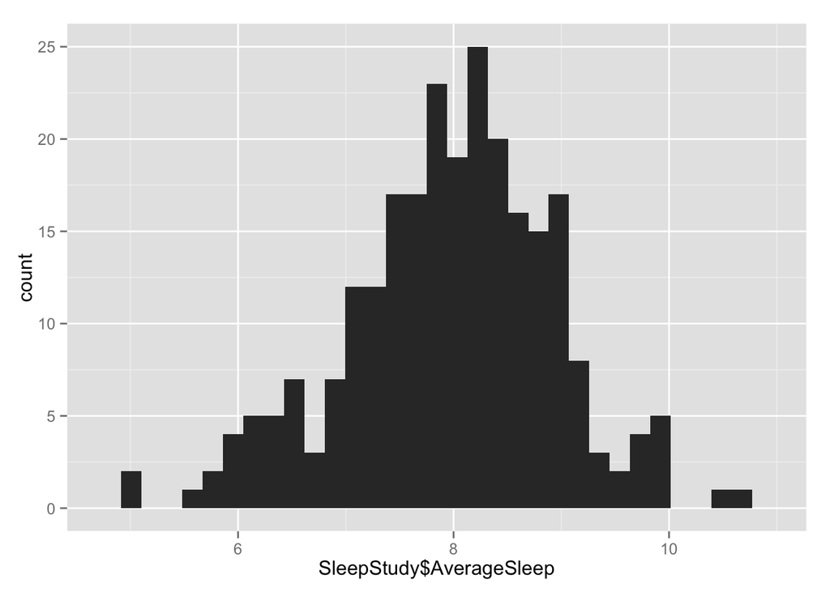

```r
qplot(SleepStudy$AverageSleep)
```

We can also plot the same thing by specfying the variable and the data set separately.

```
## stat_bin: binwidth defaulted to range/30. Use 'binwidth = x' to adjust this.
```

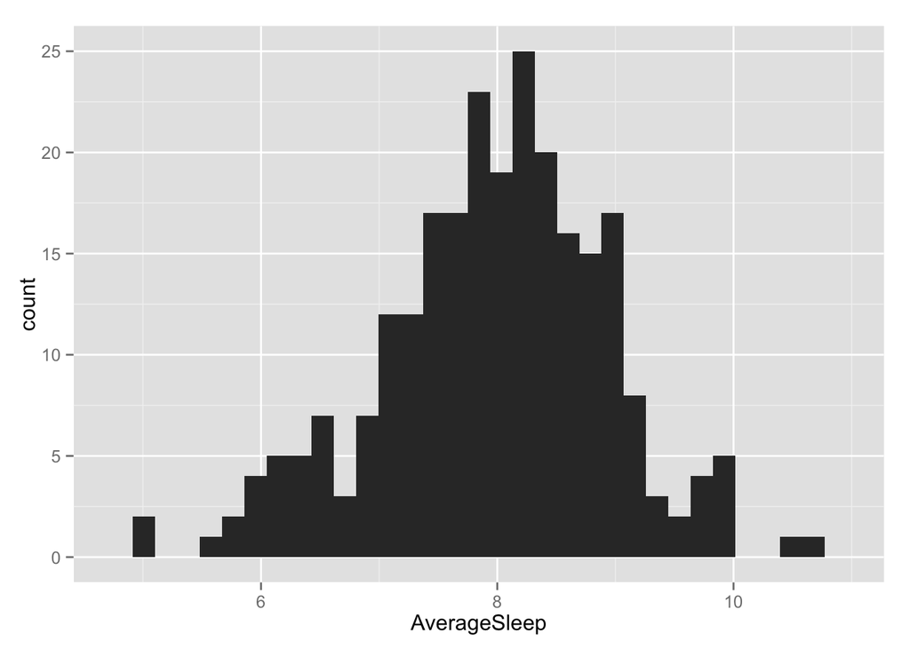

```r
qplot(AverageSleep, data=SleepStudy)
```

R’s default binwidth is the range of the data divided by 30. For our purposes, that means that R defaulted to a binwidth of:

```r
dataRange <- range(SleepStudy$AverageSleep)
dataDiff <- diff(dataRange) #computes the difference between two numbers
dataDiff/30
```

```
## [1] 0.189
```

We can change the binwidth to be either wider or more narrow.

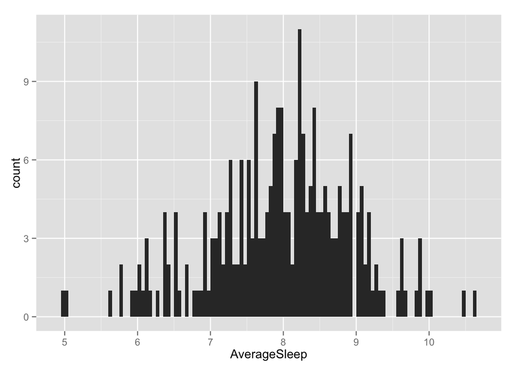

```r
qplot(AverageSleep, data=SleepStudy, binwidth=0.05)
```

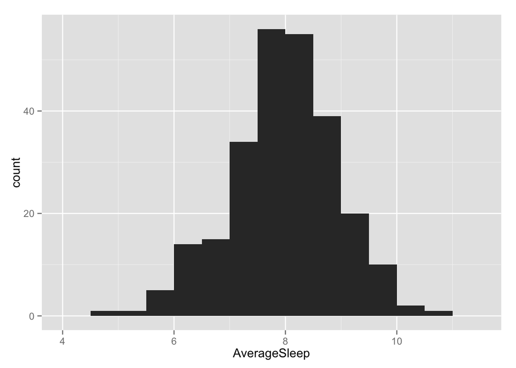

```r
qplot(AverageSleep, data=SleepStudy, binwidth=0.5)
```

### Density Plots

Density plots are another kind of plot that give us a rough outline of a histogram. Here we introduce another argument inside the `qplot` (quick plot) function by specificying the geometry, or `geom` of the plot.

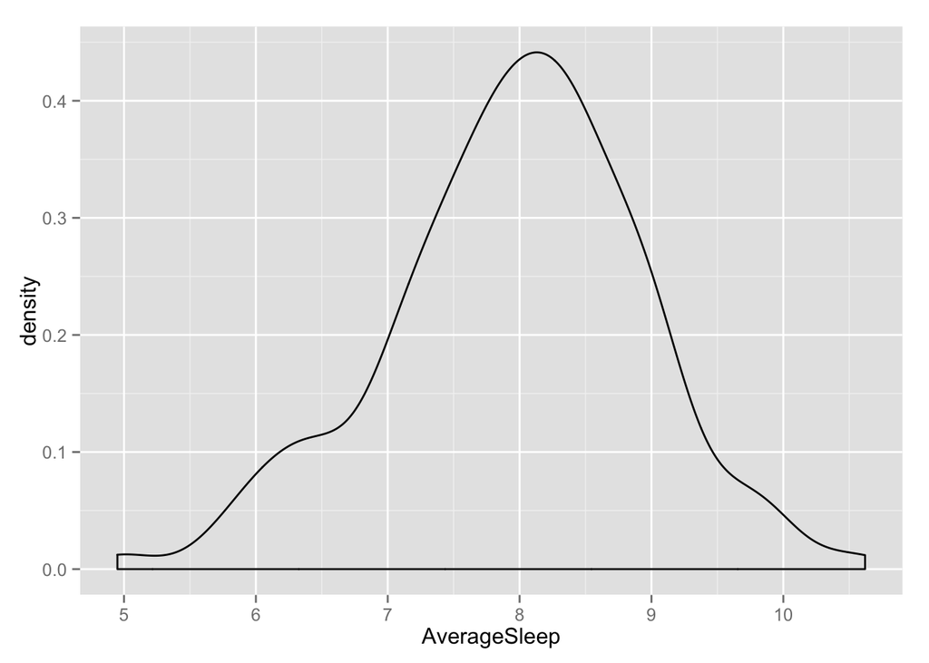

```r
qplot(AverageSleep, data=SleepStudy, geom="density")
```

### Q-Q Plots

In order to create a quantile-quantile plot, we have to install and load the `car` (Companion to Applied Regression) package.

```r
install.packages("car")
```

```r
library(car)
```

The `qqPlot` function does not have a `data=` argument, so we have to specify our data by subsetting `SleepStudy` again (if you’re ever not sure, you can just type `?qqPlot` into the console).

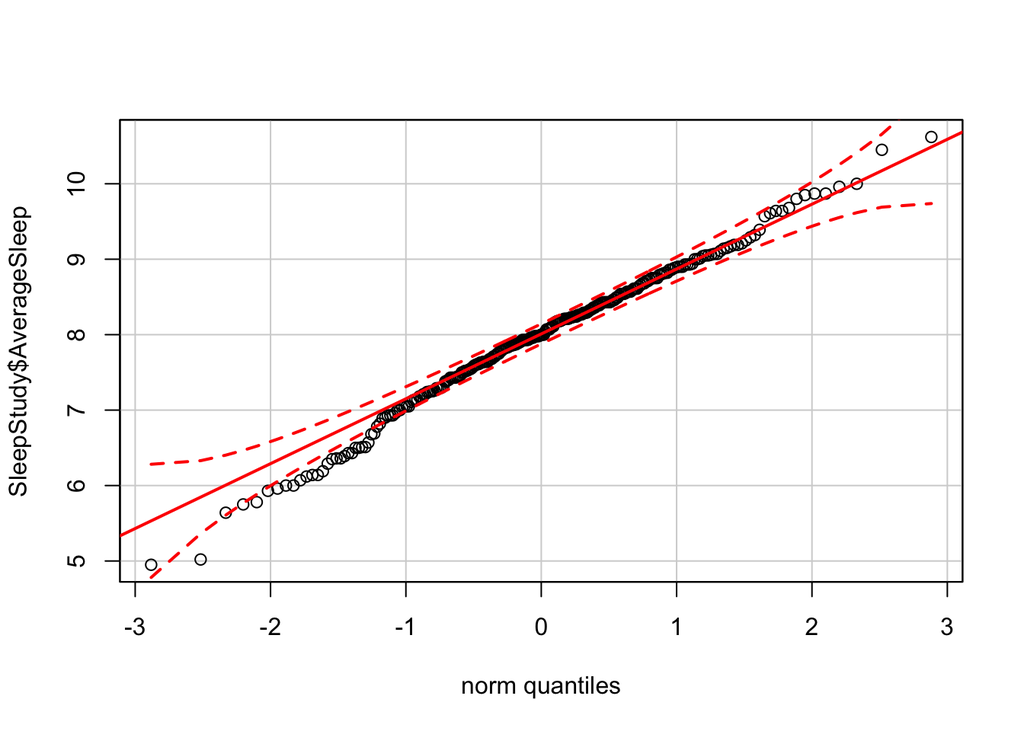

```r
qqPlot(SleepStudy$AverageSleep)
```

In order to make the dots easier to see, we can change the plotting character, or `pch`. A `pch` value of 16 is a filled circle (you can see all of the plotting character options by typing `?pch` into the console). We can do this by adding another argument to qqPlot.

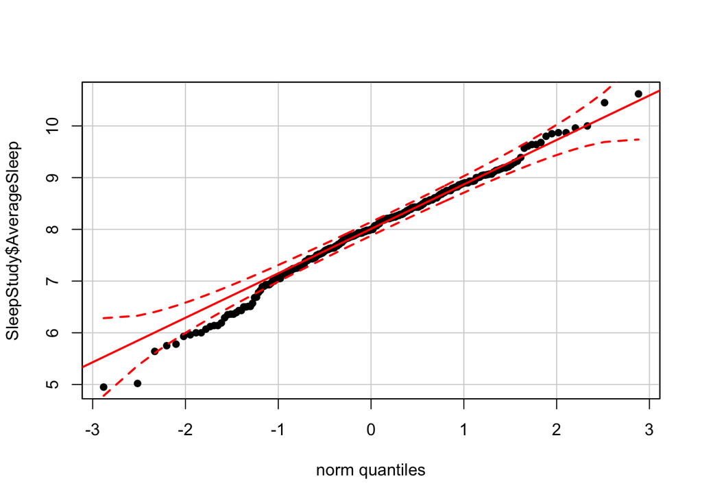

```r
qqPlot(SleepStudy$AverageSleep, pch=16)
```

## Resampling

### One Resample

Taking a single resample from a data set is pretty easy. As you know, it’s simply taking a sample with replacement from the original sample. There’s a built-in `sample` function you can use, and its arguments are pretty intuitive–you input the data you want to sample and whether or not to replace. If you don’t specify a size for the sample, R will assume you want a sample as large as the original data.

```r
(one.resample <- sample(SleepStudy$AverageSleep, replace=TRUE))
```

```
##   [1]  7.99  6.43  8.43  8.86  8.24  7.21  7.55  7.05  8.82  7.84  5.02
##  [12]  9.07  8.42  8.00  6.12  8.29  8.44  8.57  7.83  5.02  9.32  7.60
##  [23]  8.21  7.50  8.75  8.36  7.85  6.50  8.90  9.14  7.53  7.14  8.82
##  [34]  7.52  7.75  5.96  7.55  7.93  8.29  8.44  8.21  8.29  8.82  8.27
##  [45]  8.81  7.24  6.89  7.18  7.87  8.21  7.29  6.39  8.43  5.02  7.93
##  [56]  6.00  7.93  8.73  6.50  6.50  8.11  7.14  6.00  8.61  8.11  8.80
##  [67]  7.85  8.43  8.23  7.14  7.26  8.73  8.43  8.00  7.75  7.81  7.98
##  [78]  7.79  8.30  6.36  7.29  7.29  7.21  7.91  7.83  7.43  6.50  7.54
##  [89]  7.43  7.53  7.60  7.05  8.89  8.49  7.94  8.21  7.64  8.24  7.93
## [100]  7.44 10.45  8.09  6.96  8.19  8.11  8.23  7.30  8.89  8.36  8.79
## [111]  9.61  8.34  7.85  8.36  8.23  8.90  8.86  9.64  7.68  7.91  7.93
## [122]  8.46  8.75  8.16  7.90  8.54  7.85  8.29  8.88  7.98  8.80  7.32
## [133]  8.36  8.29  7.75  6.50  6.96  7.24  9.80  8.68  7.75  7.52  7.45
## [144]  8.54  6.93  8.79  8.18  8.18  8.43  8.34  8.26  7.85  9.00  6.93
## [155]  8.55  9.07  8.26  6.93  7.44  8.86  9.19  8.32  7.71  6.96  7.05
## [166]  9.87  7.29 10.00  8.81  8.54  7.43  8.18  6.68  8.59  8.82  7.64
## [177]  9.39  7.98  6.82  7.40  8.16  5.64  7.04  7.60  7.52  8.61  6.51
## [188]  7.87  7.30  6.68  8.64  7.87  9.06  7.21  6.00  6.00  5.64  7.13
## [199]  8.68  7.93  7.85  7.54  7.99  7.71  7.54  7.13  8.82  7.93  7.86
## [210]  8.24  9.15  7.29  7.21  6.14  8.32  8.27  7.68  8.04  7.18  7.00
## [221]  8.26  7.93  5.78  7.96  8.46  8.42  7.82  7.32  6.43  8.38  7.38
## [232]  7.59  8.00  9.64  8.42  7.61  6.36  8.57  8.93  7.79  9.96  8.23
## [243]  9.05  7.24  8.43  8.61  8.93  8.07  8.21  7.86  8.18  8.46  8.49
```

Let’s say you want to make a bootstrap distribution for the mean of `AverageSleep`. We then take the mean of our `one.resample`:

```r
one.mean <- mean(one.resample)
one.mean
```

```
## [1] 7.892727
```

Let’s put our `one.mean` into a data frame called `trials`, since we’re going to get a lot of means to make our bootstrap distribution. We’ll call the column of resample means that we’re collecting `result`. Because `trials` is still a small data frame, we’ll also print what `trials` looks like.

```r
trials <- data.frame(result=one.mean)
trials
```

```
##     result
## 1 7.892727
```

### Many Resamples

Now we’re ready for the big leagues. First, let’s see how we can wrap the process of taking a resample and taking a mean into one larger function:

```r
another.resample <- mean(sample(SleepStudy$AverageSleep, replace=TRUE))
another.resample
```

```
## [1] 7.913636
```

We’ve just nested the `sample` function inside the `mean` function.

As it turns out, taking a lot of samples isn’t much harder than taking one. If you haven’t already, install and load the `mosaic` package (if you’ve already installed it, you can just reload it).

```r
install.packages("mosaic")
```

```r
library(mosaic)
```

The `do` function in the `mosaic` package allows us to do one thing many times. Let’s take the mean of five resamples and print them:

```r
(do(5) * mean(sample(SleepStudy$AverageSleep, replace=TRUE)))
```

```
##     result
## 1 8.044743
## 2 8.055020
## 3 7.925178
## 4 7.933439
## 5 7.914625
```

(Note that the output of `do` is by default data frame with a column named `result`, just as we defined `trials` above.)

You can probably see where this is going. Make a data frame called `trials` of the means of 1000 resamples from `AverageSleep`. You will definitely not want to print `trials`, but we can look at the first six rows.

```r
trials <- do(1000) * mean(sample(SleepStudy$AverageSleep, replace=TRUE))
head(trials)
```

```
##     result
## 1 7.924427
## 2 7.955850
## 3 7.977945
## 4 8.038933
## 5 7.949407
## 6 8.015020
```

### Plots

How do we get a feel for a larger data set? The same way we would for a smaller one.

```r
favstats(result, data=trials)
```

```
##       min       Q1   median       Q3      max     mean         sd    n
##  7.785138 7.927451 7.966126 8.005109 8.150198 7.966692 0.05842441 1000
##  missing
##        0
```

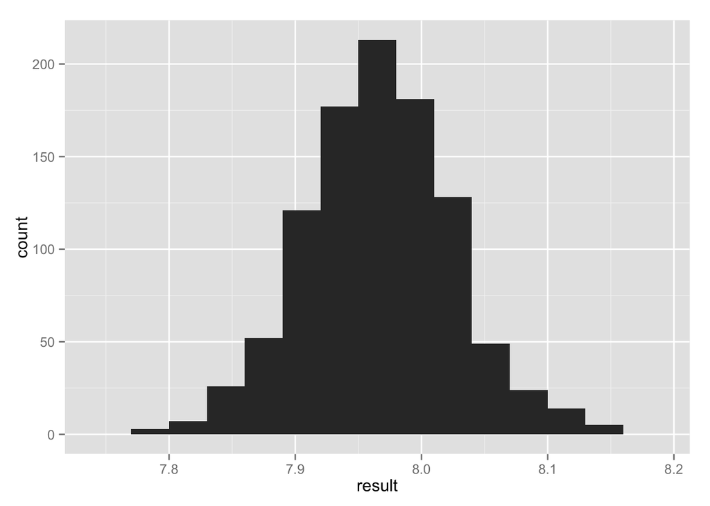

```r
qplot(result, data=trials, binwidth=0.03)
```

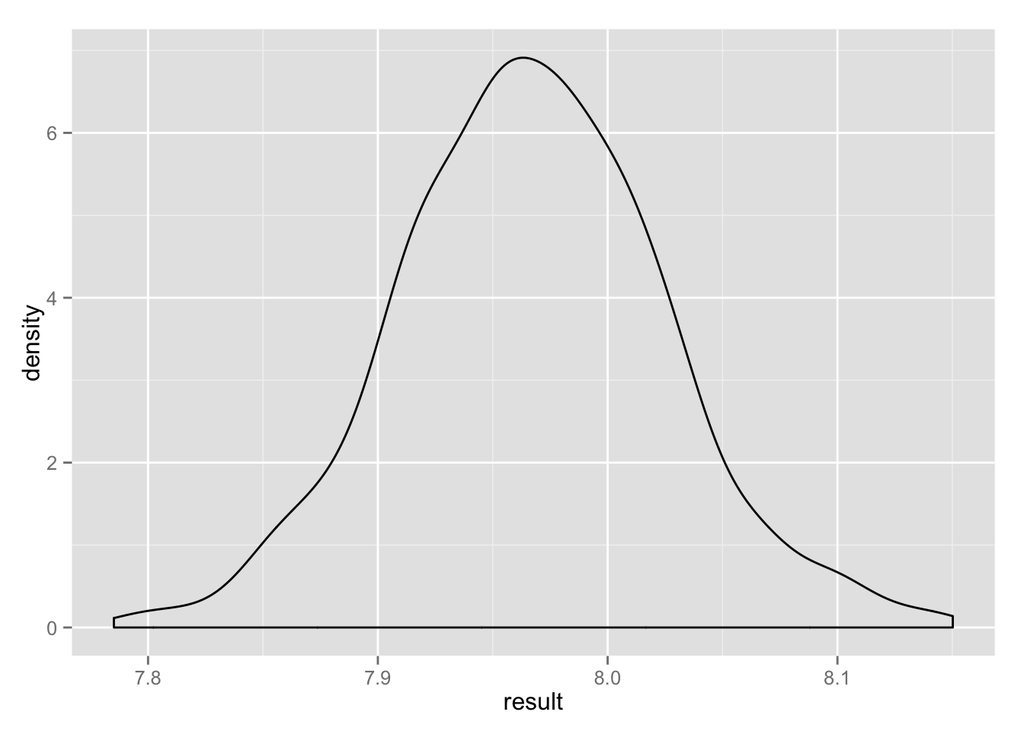

```r
qplot(result, data=trials, geom="density")
```

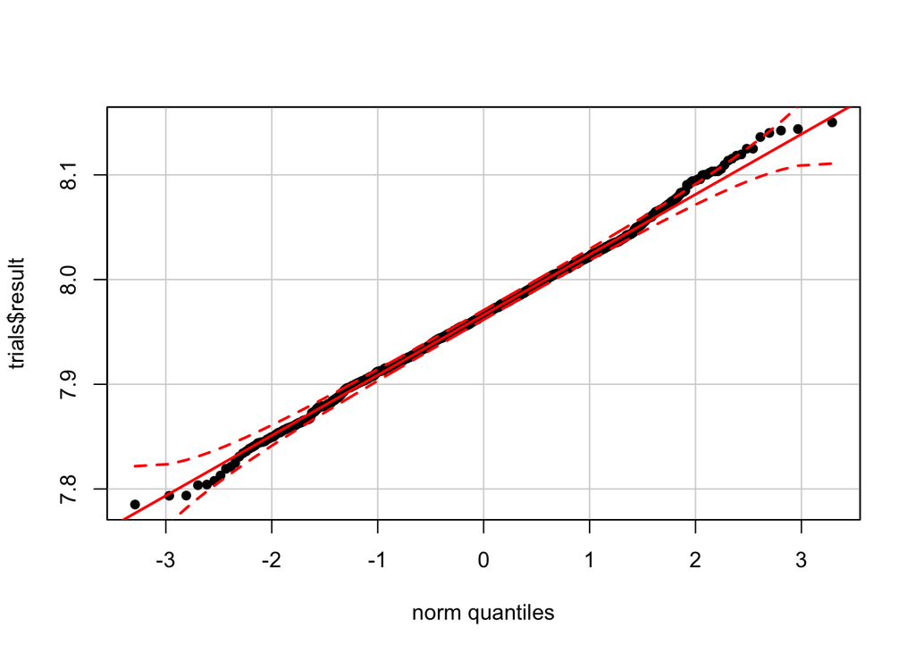

```r
qqPlot(trials$result, pch=16)
```

Those graphs represent the counts for the 1,000 resample means in the `trials` data set.

## Bias and Confidence Intervals

### Bias

So, we took a bunch of samples from a sample. What do we do with them?

We can calculate the bias, which is the difference between our original sample mean and the mean of the bootstrap distribution.

```r
mean(SleepStudy$AverageSleep) - mean(trials$result)
```

```
## [1] -0.000763083
```

### Percentile Confidence Intervals

There are two ways to calculate confidence intervals. The first one is the percentile method, which gives us sample quantiles from the data set.

First, we need to decide our confidence level. 0.95 is pretty standard, but we’ll define a variable called `level` to represent whatever number you want to put in, and a variable called `alpha` to represent the alpha level.

```r
level <- 0.95
alpha <- 1-level
```

#### Two-Tailed

A two-tailed confidence interval for the `trials` data set requires that we divide `alpha` by 2:

```r
quantile(trials$result, probs=c(alpha/2, 1-(alpha/2)))
```

```
##     2.5%    97.5%
## 7.852770 8.092413
```

#### Lower Bound

For the lower bound, we use `alpha`:

```r
quantile(trials$result, probs=alpha)
```

```
##       5%
## 7.867433
```

#### Upper Bound

For the upper bound, we use `1-alpha` (equivalent to using `level`):

```r
quantile(trials$result, probs=1-alpha)
```

```
##      95%
## 8.064933
```

### Normal Confidence Intervals

Normal-based confidence intervals use the mean of the original sample, plus or minus the standard error of the bootstrap distribution times quantiles from the normal distribution. `alpha` and `level` are used in the same way.

We will define the standard error ahead of time:

```r
SE <- sd(trials$result)
```

#### Two-Tailed

A two-tailed confidence interval for the `trials` data set requires that we divide `alpha` by 2. We will calculate the lower tail, then the upper tail.

```r
mean(SleepStudy$AverageSleep) - (qnorm(1-alpha/2) *  SE)
```

```
## [1] 7.851419
```

```r
mean(SleepStudy$AverageSleep) + (qnorm(1-alpha/2) * SE)
```

```
## [1] 8.080439
```

#### Lower Bound

For the lower bound, we use `1-alpha`, but we subtract from the mean.

```r
mean(SleepStudy$AverageSleep)  - (qnorm(1-alpha) * SE)
```

```
## [1] 7.869829
```

#### Upper Bound

For the upper bound, we also use `1-alpha`, but we add to the mean.

```r
mean(SleepStudy$AverageSleep)  + (qnorm(1-alpha) * SE)
```

```
## [1] 8.062028
```